# Programmeren in Python 3: een inleiding

### K. Verbeeck, T. Vermeulen, J. Maervoet

Data Science (Theory) -- OGI02i

## Deel 1: wat is Python en welke tools zijn er voorhanden?

### Python

- programmeertaal, °1991 door Guido Van Rossum
- Filosofie:leesbare en compacte code
  - structuur door indentatie (dus niet door {})
  - dynamisch getypeerd
- multi-paradigm: functioneel, OO, proceduraal
- referentie-implementatie: CPython
  - open-source command-line **interpreter**
  - compilatie van .py programma's naar bytecode
  - vervolgens uitgevoerd door virtuele machine

**Opgelet:** wij gebruiken Python 3 (niet compatibel met 2.*.*)

### IPython

- Verbeterde interactieve Python shell
  - tab completion, command history, introspection (bv. *docstring*)
- Kan ingebed worden in en communiceren met andere programma's
- Kernel: verschillende clients kunnen instructies doorsturen voor evaluatie naar hetzelfde proces

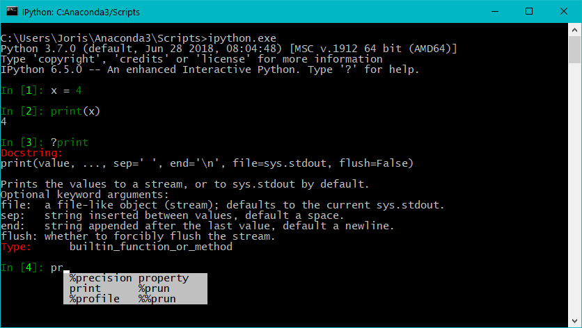

### Jupyter Notebook

- Een interactieve webapplicatie om *notebook* documenten (.ipynb **[formaat](https://nbformat.readthedocs.io/en/latest/format_description.html#)**) te creëren en te delen
- Rijke documenten met uitvoerbare (Python-)code, begeleidende tekst, figuren, ...
- Export naar tal van formaten met nbconvert

[figure not shown]

### Een Jupyter *notebook* editeren

- 3 soorten cellen
  - Markdown-cellen (**syntax**)
  - Code-cellen
    - Rechtstreekse interactie met IPython kernel
    - Kunnen een output hebben
  - Cellen met rauwe nbconvert data

[figure not shown]

### Makkelijk starten met Anaconda

- **Anaconda:** een Python-distributie voor data science met package manager
- Link: **https://www.anaconda.com/distribution/**
- Bevat de interpreter en ook klassieke libraries (onder Environments)

[figure not shown]

### Meer informatie

- **[The Python Tutorial](https://docs.python.org/3/tutorial/)**
- **[IPython overview/documentation](https://ipython.readthedocs.io/en/stable/overview.html)**
- **[Jupyter notebook documentation](https://jupyter-notebook.readthedocs.io/en/stable/notebook.html)**

## Deel 2: programmeren in Python

### Variabelen en evaluatie van expressies

```python
# dit is commentaar
10 / 3
```

```
3.3333333333333335
```

```python
berekening = 5 * 6 + 3
print(berekening)
print(10 // 3) # gehele deling
print(10 ** 3) # machtsverheffing
```

```
33
3
1000
```

```python
# 4 basisdatatypes: int float str bool

getal = input('Geef een getal: ')
print(float(getal) / 5) # type conversion; anders TypeError door operator /
```

```
Geef een getal: 3
0.6
```

### Strings (1)

```python
langetekst = ('Lorem ipsum '
              'omnis mundi creaturi')
print(langetekst)
woord = 'py' + 'thon' * 2
print(woord + '\n')
print("He didn't say " + '"hello"')
print(r'\n')
```

```
Lorem ipsum omnis mundi creaturi
pythonthon

He didn't say "hello"
\n
```

```python
#formatting
print('{1} and {0}'.format('spam', 'eggs'))
```

```
eggs and spam
```

```python
# include line ends using tripe-quotes
print("""\
Usage: thingy [OPTIONS]
     -h                        Display this usage message
     -H hostname               Hostname to connect to
""")
```

```
Usage: thingy [OPTIONS]
     -h                        Display this usage message
     -H hostname               Hostname to connect to
```

### Strings (2)

```python
woord = 'python'
print(len(woord)) # lengte van een string

# indexing and slicing
print('[1]: ' + woord[1])
print('[2:4]: ' + woord[2:4])
print('[-1]: ' + woord[-1])
print('[4:]: ' + woord[4:])
print('[:4]: ' + woord[:4])
```

```
6
[1]: y
[2:4]: th
[-1]: n
[4:]: on
[:4]: pyth
```

```python
woord[0] = 'k'  # strings zijn onveranderlijk ...
```

```
---------------------------------------------------------------------------
TypeError                                 Traceback (most recent call last)
<ipython-input-8-ffa2d4d2d48e> in <module>
----> 1 woord[0] = 'k'  # strings zijn onveranderlijk ...

TypeError: 'str' object does not support item assignment
```

### Lists

```python
squares = [1, 4, 9, 16, 25]

# indexing and slicing
print(squares[0])
print(squares[-3:])

squares.append(36)
squares += [100, 121]
squares[6:8] = [49]
print(squares)
mycopy = squares[:] # shallow copy
print(len(squares))
```

```
1
[9, 16, 25]
[1, 4, 9, 16, 25, 36, 49]
7
```

### Control flow (1)

```python
x = 5
if x < 0:
    print('negatief')
elif x == 0:
    print('nul')
else:
    print('positief')
print(x)
```

```
positief
5
```

```python
lijst = ['a', 'bb', 'ccc']
for woord in lijst:
    print(woord, len(woord))
```

```
a 1
bb 2
ccc 3
```

### Control flow (2)

```python
for i in range(5):
    print(i)
```

```
0
1
2
3
4
```

```python
print(range(0, 10, 3)) # hmmm... eigenlijk is dit een object
print(list(range(0, 10, 3)))
```

```
range(0, 10, 3)
[0, 3, 6, 9]
```

```python
# na : is een statement vereist
# gebruik pass als je geen actie vereist (pass doet niets)
for i in range(5):
    pass
```

### Functies

```python
def ask_ok(prompt, retries=4, reminder='Please try again!'): # default args
    """Asks the user for confirmation""" # dit is de docstring
    while True:
        ok = input(prompt)
        if ok in ('y', 'ye', 'yes'):
            return True
        if ok in ('n', 'no', 'nop', 'nope'):
            return False
        retries = retries - 1
        if retries < 0:
            raise ValueError('invalid user response')
        print(reminder)

ask_ok('OK to overwrite the file?', 2)
```

```
OK to overwrite the file?maybe
Please try again!
OK to overwrite the file?y
```

```
True
```

```python
ask_ok("is 't okee?", retries=0) # keyword arguments (steeds na postional args)
```

```
is 't okee?y
```

```
True
```

### Datastructures: lists (continued)

```python
fruits = ['orange', 'apple', 'pear', 'banana', 'kiwi', 'apple', 'banana']
print(fruits.count('apple'))
fruits.sort()
fruits.reverse()
print(fruits)
del fruits[1:2]

stack = [3, 4, 5]
stack.pop()
print(stack)
```

```
2
['pear', 'orange', 'kiwi', 'banana', 'banana', 'apple', 'apple']
[3, 4]
```

```python
# list comprehension
squares = [x**2 for x in range(10)]
print(squares)
vec = [-4, -2, 0, 2, 4]
print([x for x in vec if x >= 0])
```

```
[0, 1, 4, 9, 16, 25, 36, 49, 64, 81]
[0, 2, 4]
```

### Datastructures: tuples

```python
resultaat = 25, 'Gent' # typisch voor heterogene data
print(resultaat[1]);
empty = ()
singleton = 'hello',
v = ([1, 2, 3], [3, 2, 1])  # tuples zijn onveranderlijk, hun elementen eventueel wel ...
print(len(singleton), len(v))
```

```
Gent
1 2
```

```python
# de iterator van enumerate geeft tuples terug
for i, v in enumerate(['tic', 'tac', 'toe']):
    print(i, v)
```

```
0 tic
1 tac
2 toe
```

### Datastructures: sets (verzamelingen)

```python
verzameling1 = {'A', 'B', 'C', 'D'}
verzameling2 = set('DAXYDA') # omzetten van lists, strings, ... naar een set
print(verzameling2)
print('A' in verzameling1) # snel opzoeken
print(verzameling1 | verzameling2) # unie
print(verzameling1 & verzameling2) # doorsnede
```

```
{'D', 'A', 'X', 'Y'}
True
{'C', 'X', 'A', 'Y', 'B', 'D'}
{'D', 'A'}
```

```python
# set comprehension
a = {x for x in 'abracadabra' if x not in 'abc'}
print(a)
```

```
{'r', 'd'}
```

### Datastructures: dictionaries

```python
tel = {'jack': 4098, 'sape': 4139}
tel['guido'] = 4127

if 'jack' in tel: # snel opzoeken
    print(tel['jack'])
```

```
4098
```

```python
tel2 = dict(sape=4139, guido=4127, jack=4098) # je kan ook een lijst van koppels gebruiken
del tel2['sape']
print(tel2)
for k, v in tel2.items():
    print(k, v)
```

```
{'guido': 4127, 'jack': 4098}
guido 4127
jack 4098
```

### *args en **kwargs

- *args verwijst naar een lijst van (onbenoemde) argumenten van een functie
- **kwargs verwijst naar een dictionary van keyword-argumenten van een functie
- kunnen als argument gebruikt worden van een functie

```python
def greetMe(name, **kwargs):
    salutation = kwargs['sal'] if ('sal' in kwargs) else "Hallo" # omg it's a ternary operator
    print(salutation + ' ' + name)

greetMe('Joris', sal='Hoi')
```

```
Hoi Joris
```

- in principe kan om het even welke variabelenaam gebruikt worden, als de sterren er maar staan
- *args en **kwargs worden steevast gebruikt in de documentatie van libraries

### Anonieme functies met *lambda*

```python
add = lambda x, y: x + y
add(5, 6)
```

```
11
```

```python
a = [(1, 2), (4, 1), (9, 10), (13, -3)]
a.sort(key=lambda x: x[1])
print(a)
```

```
[(13, -3), (4, 1), (1, 2), (9, 10)]
```

```python
items = [1, 2, 3, 4, 5]
squared = list(map(lambda x: x**2, items)) # map returns an iterator
print(squared)
odd = list(filter(lambda x: x % 2 == 1, squared)) # filter returns an iterator
print(odd)
```

```
[1, 4, 9, 16, 25]
[1, 9, 25]
```

### Is dit alles?

- nee zeker niet, dit waren maar stukjes uit de **[Python 3 tutorial](https://docs.python.org/3/tutorial/)**
- zeer toegankelijke cursus: **[geo-python](https://geo-python.github.io/site/index.html)**
- de officiële documentatie van **The Python Standard Library** vind je **[hier](https://docs.python.org/3/library/)**
- leuke tips als je al een beetje Python kan: **[Intermediate Python Tips](https://book.pythontips.com/en/latest/index.html)**

## Deel 3: libraries: een voorproefje ...

### Import

- Een module ~ een bestand
- Een package ~ een verzameling modules in een mappenhiërarchie
- In een module zitten items (functies, klassen, ...) aan te roepen met .

```python
import math # importeren van de math module

print('pi is', math.pi)
```

```
pi is 3.141592653589793
```

```python
import math as wiskunde

print('pi is', wiskunde.pi)
```

```
pi is 3.141592653589793
```

```python
from math import cos, pi # from laat toe items, modules te importeren (en jokerteken *)

print('cos(pi) is', cos(pi))
```

```
cos(pi) is -1.0
```

### De NumPy library

- Performante ondersteuning voor grote multi-dimensionele arrays (matrices) en bijhorende operatoren uit de numerieke wiskunde
- Centrale datastructuur: *ndarray*
- **[Quickstart](https://docs.scipy.org/doc/numpy/user/quickstart.html)**
- Hier komen we volgende week op terug

```python
import numpy as np

a = np.array([1, 2, 3])
print(a[0], type(a))
print(a)

print(np.arange(0, 3, 0.25)) # standard python kan geen ranges met kommagetallen genereren
```

```
1 <class 'numpy.ndarray'>
[1 2 3]
[0.   0.25 0.5  0.75 1.   1.25 1.5  1.75 2.   2.25 2.5  2.75]
```

```python
d = np.eye(3)
print(d)
e = np.full((3,3), 7)
print(e)
print(d*e)
```

```
[[1. 0. 0.]
 [0. 1. 0.]
 [0. 0. 1.]]
[[7 7 7]
 [7 7 7]
 [7 7 7]]
[[7. 0. 0.]
 [0. 7. 0.]
 [0. 0. 7.]]
```

## Matplotlib

- Kwaliteitsvolle 2D-plot-bibliotheek
- Startpunt: de **[matplotlib tutorials](https://matplotlib.org/tutorials/index.html)**

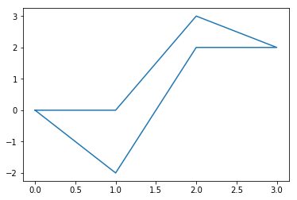

```python
import matplotlib.pyplot as plt

# Some nice x and y coordinates
x = [0, 1, 2, 3, 2, 1, 0]
y = [0, 0, 3, 2, 2, -2, 0]

# Plot the points using matplotlib
plt.plot(x, y)
plt.show()
```

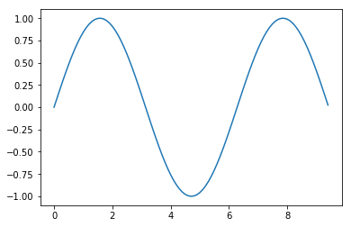

```python
import numpy as np
import matplotlib.pyplot as plt

# Compute the x and y coordinates for points on a sine curve
x = np.arange(0, 3 * np.pi, 0.1)
y = np.sin(x)

# Plot the points using matplotlib
plt.plot(x, y)
plt.show()
```

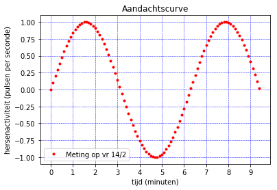

```python
import numpy as np
import matplotlib.pyplot as plt

# Compute the x and y coordinates for points on a sine curve
x = np.arange(0, 3 * np.pi, 0.1)
y = np.sin(x)

# Plot the points using matplotlib with labels, a title, ticks, a grid and a legend
plt.plot(x, y, 'r.')
plt.xlabel('tijd (minuten)')
plt.ylabel('hersenactiviteit (pulsen per seconde)')
plt.title('Aandachtscurve')
plt.xticks(range(0,10))
plt.grid(color='b', linestyle='--', linewidth=.5)
plt.legend(['Meting op vr 14/2'])
plt.show()
```

[figure not shown]